# Alcohol drinking

# 1 Description of DataSchema variable

The description of harmonised variables is the following:

- Short name: `current_oh`
- Variable label: `Current alcohol drinker`
- Variable description: `Current alcohol drinker`
- Domain: `Lifestyle and health behaviours`
- Value type: `categorical`
- Category coding:

| **Code** | **Category Label** |
| --- | --- |
| 0 | No |
| 1 | Yes |

- Category missings:

| **Code** | **Category Label** |
| --- | --- |
| 991 | CAPI/interviewer error |
| 992 | Impute |
| 993 | Disable to measure |
| 994 | Not attempt/not done |
| 995 | Does not answer |
| 996 | Not applicable |
| 997 | Refuse |
| 998 | Do not know |
| 999 | Missing |

- Short name: `freq_oh`
- Variable label: `Frequency of alcohol drinking`
- Variable description: `Frequency of alcohol drinking`
- Domain: `Lifestyle and health behaviours`
- Value type: `categorical`
- Category coding:

| **Code** | **Category Label** |
| --- | --- |
| 0 | never |
| 1 | rare |
| 2 | often |

- Category missings:

| **Code** | **Category Label** |
| --- | --- |
| 991 | CAPI/interviewer error |
| 992 | Impute |
| 993 | Disable to measure |
| 994 | Not attempt/not done |
| 995 | Does not answer |
| 996 | Not applicable |
| 997 | Refuse |
| 998 | Do not know |
| 999 | Missing |

- Short name: `past_oh`
- Variable label: `Past drinking`
- Variable description: `Did you drink in the past?`
- Domain: `Lifestyle and health behaviours`
- Value type: `categorical`
- Category coding:

| **Code** | **Category Label** |
| --- | --- |
| 0 | No |
| 1 | Yes |

- Category missings:

| **Code** | **Category Label** |
| --- | --- |
| 991 | CAPI/interviewer error |
| 992 | Impute |
| 993 | Disable to measure |
| 994 | Not attempt/not done |
| 995 | Does not answer |
| 996 | Not applicable |
| 997 | Refuse |
| 998 | Do not know |
| 999 | Missing |

# 2 Data process

## 2.1 England

### 2.1.1 Wave 1

#### 2.1.1.1 Study-specific variable description

| **Name** | `heala` |
| --- | --- |
| **Label** | `In the past 12 months have you taken an alcoholic drink .? {frequency}` |
| **Table name** | `wave_1_core_data_v3` |
| **Categories** | `1 = ... twice a day or more,` `2 = daily or almost daily,` `3 = once or twice a week,` `4 = once or twice a month,` `5 = special occasions only,` `6 = or, not at all?` |
| **Missings** | `-1 = Not applicable` `-8 = Don't Know` `-9 = Refusal` |
| **Description** |  |

heala

| Sample size | Missing values |
| --- | --- |
| 12099 | 195 |

Category

|  | 1 | 2 | 3 | 4 | 5 | 6 |
| --- | --- | --- | --- | --- | --- | --- |
| Frequency | 506.00 | 2816.00 | 3614.00 | 1258.0 | 2315.00 | 1395.00 |
| Percentage | 4.18 | 23.27 | 29.87 | 10.4 | 19.13 | 11.53 |

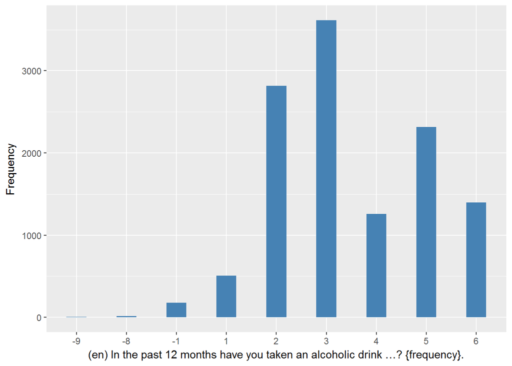

#### 2.1.1.2 Harmonisation algorithm

To compute `current_oh` from the study-specific variable it has to be recoded as follows:

- `1,2,3,4,5 into 1`
- `6 into 0`
- `-1 into 996`
- `-8 into 998`
- `-9 into 997`

To compute `freq_oh` from the study-specific variable it has to be recoded as follows:

- `1,2 into 2`
- `3,4,5 into 1`
- `6 into 0`
- `-1 into 996`
- `-8 into 998`
- `-9 into 997`

**R script:**

```r
ELSA_ds_w1 <- tibble(id = ELSA_w1$id)
ELSA_ds_w1$current_oh <- car::recode(ELSA_w1$heala, "c(1,2,3,4,5) = 1; c(6) = 0; -1 = 996; -8 = 998; -9 = 997")
ELSA_ds_w1$freq_oh <- car::recode(ELSA_w1$heala, "c(1,2) = 2; c(3,4,5) = 1; c(6) = 0; -1 = 996; -8 = 998; -9 = 997")
```

#### 2.1.1.3 Statistics of the new harmonized variable

Current alcohol drinker

| Sample size | Missing values |
| --- | --- |
| 12099 | 195 |

Category

|  | 0 | 1 |
| --- | --- | --- |
| Frequency | 1395.00 | 10509.00 |
| Percentage | 11.53 | 86.86 |

Type of missing

|  | 991 | 992 | 993 | 994 | 995 | 996 | 997 | 998 | 999 | NA |
| --- | --- | --- | --- | --- | --- | --- | --- | --- | --- | --- |
| Frequency | 0 | 0 | 0 | 0 | 0 | 175.00 | 5.00 | 15.00 | 0 | 0 |
| Percentage | 0 | 0 | 0 | 0 | 0 | 1.45 | 0.04 | 0.12 | 0 | 0 |

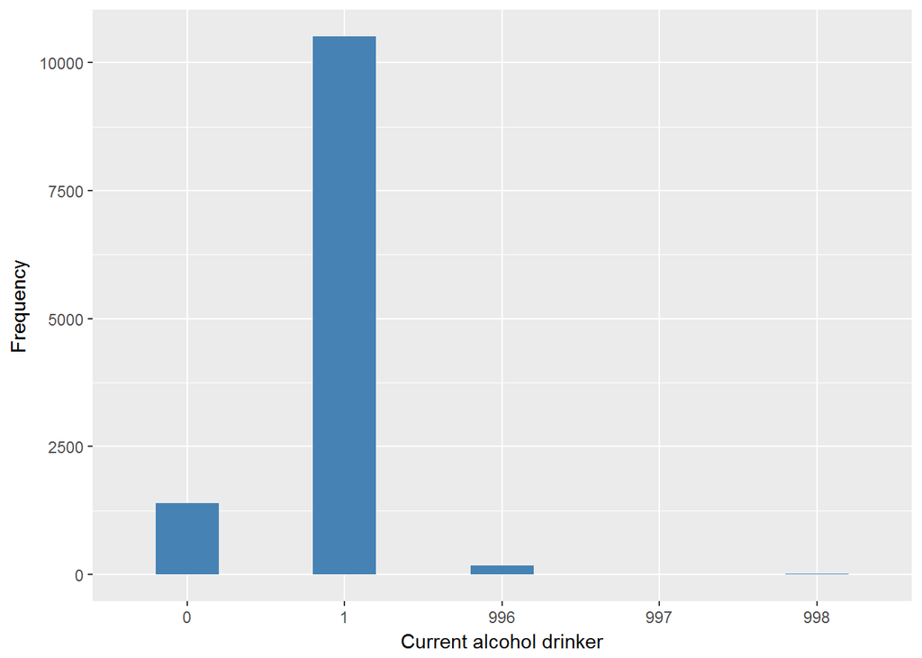

Frequency of alcohol drinking

| Sample size | Missing values |
| --- | --- |
| 12099 | 195 |

Category

|  | 0 | 1 | 2 |
| --- | --- | --- | --- |
| Frequency | 1395.00 | 7187.0 | 3322.00 |
| Percentage | 11.53 | 59.4 | 27.46 |

Type of missing

|  | 991 | 992 | 993 | 994 | 995 | 996 | 997 | 998 | 999 | NA |
| --- | --- | --- | --- | --- | --- | --- | --- | --- | --- | --- |
| Frequency | 0 | 0 | 0 | 0 | 0 | 175.00 | 5.00 | 15.00 | 0 | 0 |
| Percentage | 0 | 0 | 0 | 0 | 0 | 1.45 | 0.04 | 0.12 | 0 | 0 |

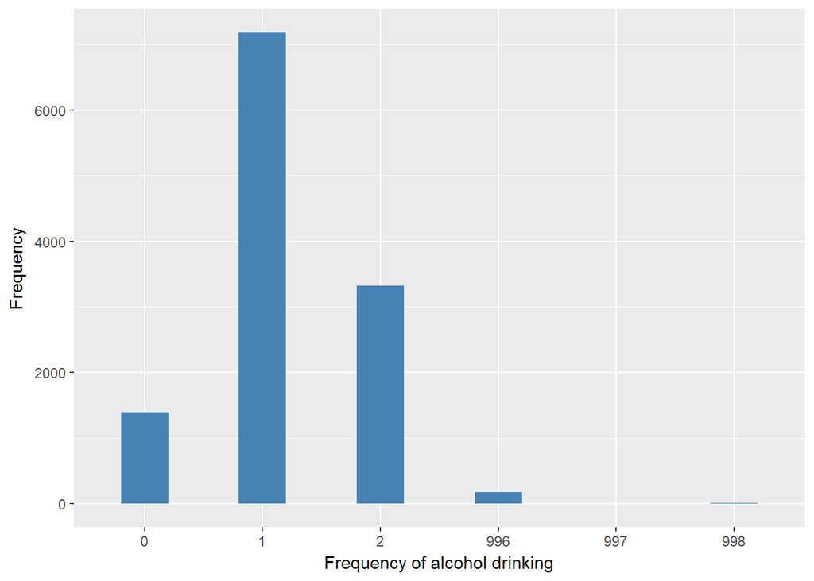

#### 2.1.1.4 Validation

### 2.1.2 Wave 2

#### 2.1.2.1 Study-specific variable description

| **Name** | `scako` |
| --- | --- |
| **Label** | `How often respondent has had an alcoholic drink during the last 12 months` |
| **Table name** | `wave_2_core_data_v4` |
| **Categories** | `1 = Almost every day` `2 = Five or six days a week` `3 = Three or four days a week` `4 = Once or twice a week` `5 = Once or twice a month` `6 = Once every couple of months` `7 = Once or twice a year`… |
| **Missings** | `-1 = Item not applicable` `-9 = Not answered` |
| **Description** |  |

scako

| Sample size | Missing values |
| --- | --- |
| 9432 | 1288 |

Category

|  | 1 | 2 | 3 | 4 | 5 | 6 | 7 | 8 |
| --- | --- | --- | --- | --- | --- | --- | --- | --- |
| Frequency | 1457.00 | 463.00 | 968.00 | 2094.0 | 983.00 | 560.00 | 736.0 | 883.00 |
| Percentage | 15.45 | 4.91 | 10.26 | 22.2 | 10.42 | 5.94 | 7.8 | 9.36 |

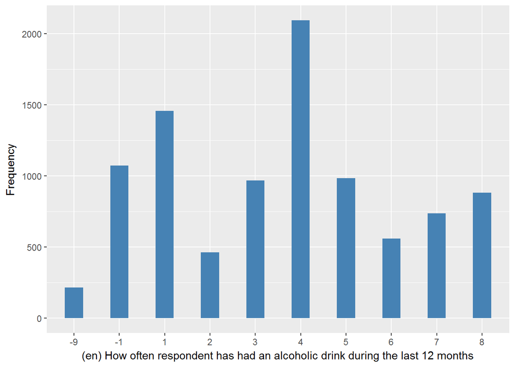

#### 2.1.2.2 Harmonisation algorithm

To compute `current_oh` from the study-specific variable it has to be recoded as follows:

- `1,2,3,4,5,6,7 into 1`
- `8 into 0`
- `-1 into 996`
- `-9 into 995`

To compute `freq_oh` from the study-specific variable it has to be recoded as follows:

- `1,2,3 into 2`
- `4,5,6,7 into 1`
- `8 into 0`
- `-1 into 996`
- `-9 into 995`

**R script:**

```r
ELSA_ds_w2 <- tibble(id = ELSA_w2$id)
ELSA_ds_w2$current_oh <- car::recode(ELSA_w2$scako, "c(1,2,3,4,5,6,7) = 1; c(8) = 0; -1 = 996; -9 = 995")
ELSA_ds_w2$freq_oh <- car::recode(ELSA_w2$scako, "c(1,2,3) = 2; c(4,5,6,7) = 1; c(8) = 0; -1 = 996; -9 = 995")
```

#### 2.1.2.3 Statistics of the new harmonized variable

Current alcohol drinker

| Sample size | Missing values |
| --- | --- |
| 9432 | 1288 |

Category

|  | 0 | 1 |
| --- | --- | --- |
| Frequency | 883.00 | 7261.00 |
| Percentage | 9.36 | 76.98 |

Type of missing

|  | 991 | 992 | 993 | 994 | 995 | 996 | 997 | 998 | 999 | NA |
| --- | --- | --- | --- | --- | --- | --- | --- | --- | --- | --- |
| Frequency | 0 | 0 | 0 | 0 | 216.00 | 1072.00 | 0 | 0 | 0 | 0 |
| Percentage | 0 | 0 | 0 | 0 | 2.29 | 11.37 | 0 | 0 | 0 | 0 |

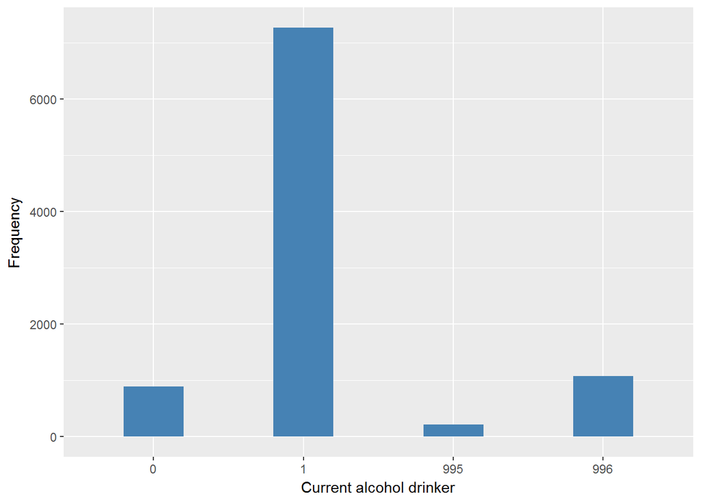

Frequency of alcohol drinking

| Sample size | Missing values |
| --- | --- |
| 9432 | 1288 |

Category

|  | 0 | 1 | 2 |
| --- | --- | --- | --- |
| Frequency | 883.00 | 4373.00 | 2888.00 |
| Percentage | 9.36 | 46.36 | 30.62 |

Type of missing

|  | 991 | 992 | 993 | 994 | 995 | 996 | 997 | 998 | 999 | NA |
| --- | --- | --- | --- | --- | --- | --- | --- | --- | --- | --- |
| Frequency | 0 | 0 | 0 | 0 | 216.00 | 1072.00 | 0 | 0 | 0 | 0 |
| Percentage | 0 | 0 | 0 | 0 | 2.29 | 11.37 | 0 | 0 | 0 | 0 |

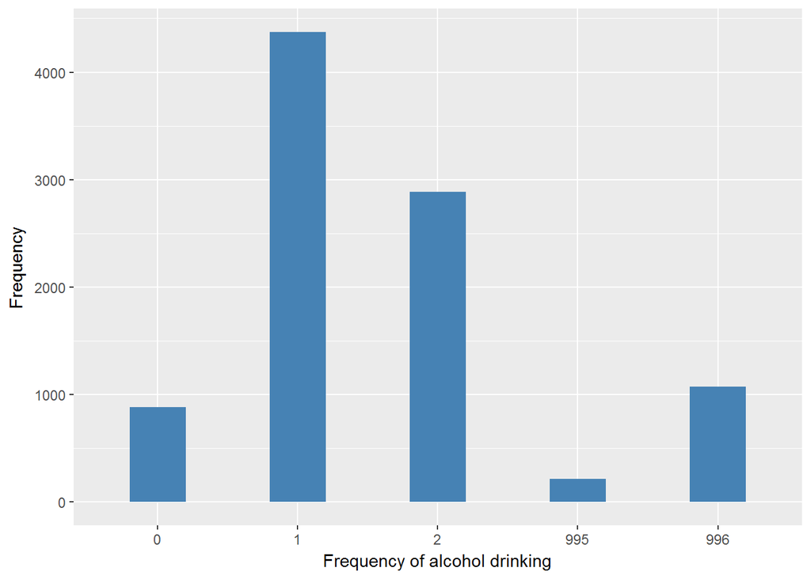

#### 2.1.2.4 Validation

### 2.1.3 Wave 3

#### 2.1.3.1 Study-specific variable description

| **Name** | `scako` |
| --- | --- |
| **Label** | `How often respondent has had an alcoholic drink during the last 12 months` |
| **Table name** | `wave_3_elsa_data_v4` |
| **Categories** | `1 = Almost every day` `2 = Five or six days a week` `3 = Three or four days a week` `4 = Once or twice a week` `5 = Once or twice a month` `6 = Once every couple of months` `7 = Once or twice a year`… |
| **Missings** | `-1 = Item not applicable` `-9 = Not answered` |
| **Description** |  |

scako

| Sample size | Missing values |
| --- | --- |
| 9771 | 1854 |

Category

|  | 1 | 2 | 3 | 4 | 5 | 6 | 7 | 8 |
| --- | --- | --- | --- | --- | --- | --- | --- | --- |
| Frequency | 1320.00 | 480.00 | 1018.00 | 2019.00 | 946.00 | 569.00 | 686.00 | 879 |
| Percentage | 13.51 | 4.91 | 10.42 | 20.66 | 9.68 | 5.82 | 7.02 | 9 |

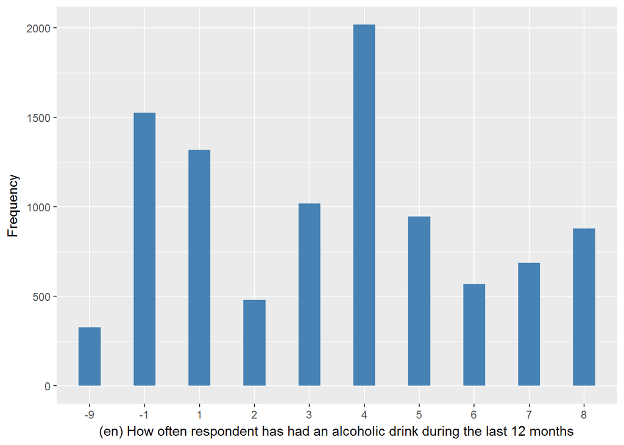

#### 2.1.3.2 Harmonisation algorithm

To compute `current_oh` from the study-specific variable it has to be recoded as follows:

- `1,2,3,4,5,6,7 into 1`
- `8 into 0`
- `-1 into 996`
- `-9 into 995`

To compute `freq_oh` from the study-specific variable it has to be recoded as follows:

- `1,2,3 into 2`
- `4,5,6,7 into 1`
- `8 into 0`
- `-1 into 996`
- `-9 into 995`

**R script:**

```r
ELSA_ds_w3 <- tibble(id = ELSA_w3$id)
ELSA_ds_w3$current_oh <- car::recode(ELSA_w3$scako, "c(1,2,3,4,5,6,7) = 1; c(8) = 0; -1 = 996; -9 = 995")
ELSA_ds_w3$freq_oh <- car::recode(ELSA_w3$scako, "c(1,2,3) = 2; c(4,5,6,7) = 1; c(8) = 0; -1 = 996; -9 = 995")
```

#### 2.1.3.3 Statistics of the new harmonized variable

Current alcohol drinker

| Sample size | Missing values |
| --- | --- |
| 9771 | 1854 |

Category

|  | 0 | 1 |
| --- | --- | --- |
| Frequency | 879 | 7038.00 |
| Percentage | 9 | 72.03 |

Type of missing

|  | 991 | 992 | 993 | 994 | 995 | 996 | 997 | 998 | 999 | NA |
| --- | --- | --- | --- | --- | --- | --- | --- | --- | --- | --- |
| Frequency | 0 | 0 | 0 | 0 | 327.00 | 1527.00 | 0 | 0 | 0 | 0 |
| Percentage | 0 | 0 | 0 | 0 | 3.35 | 15.63 | 0 | 0 | 0 | 0 |

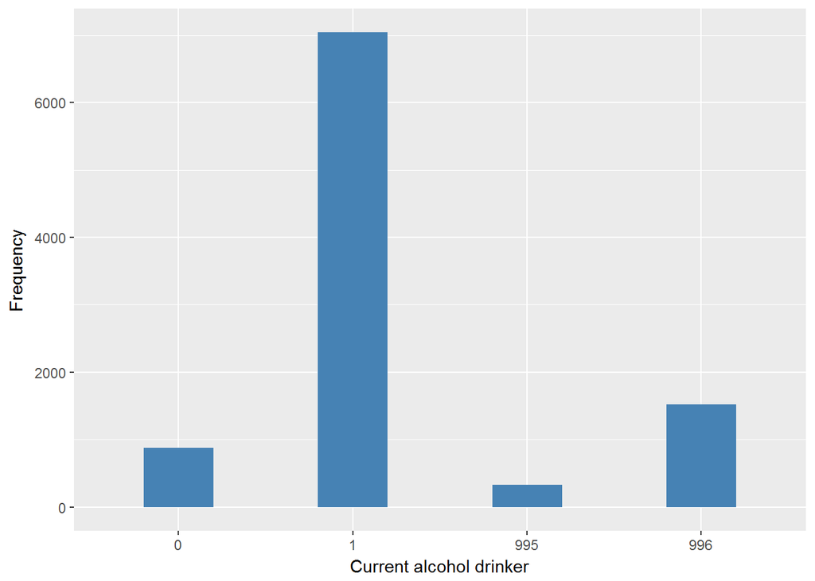

Frequency of alcohol drinking

| Sample size | Missing values |
| --- | --- |
| 9771 | 1854 |

Category

|  | 0 | 1 | 2 |
| --- | --- | --- | --- |
| Frequency | 879 | 4220.00 | 2818.00 |
| Percentage | 9 | 43.19 | 28.84 |

Type of missing

|  | 991 | 992 | 993 | 994 | 995 | 996 | 997 | 998 | 999 | NA |
| --- | --- | --- | --- | --- | --- | --- | --- | --- | --- | --- |
| Frequency | 0 | 0 | 0 | 0 | 327.00 | 1527.00 | 0 | 0 | 0 | 0 |
| Percentage | 0 | 0 | 0 | 0 | 3.35 | 15.63 | 0 | 0 | 0 | 0 |

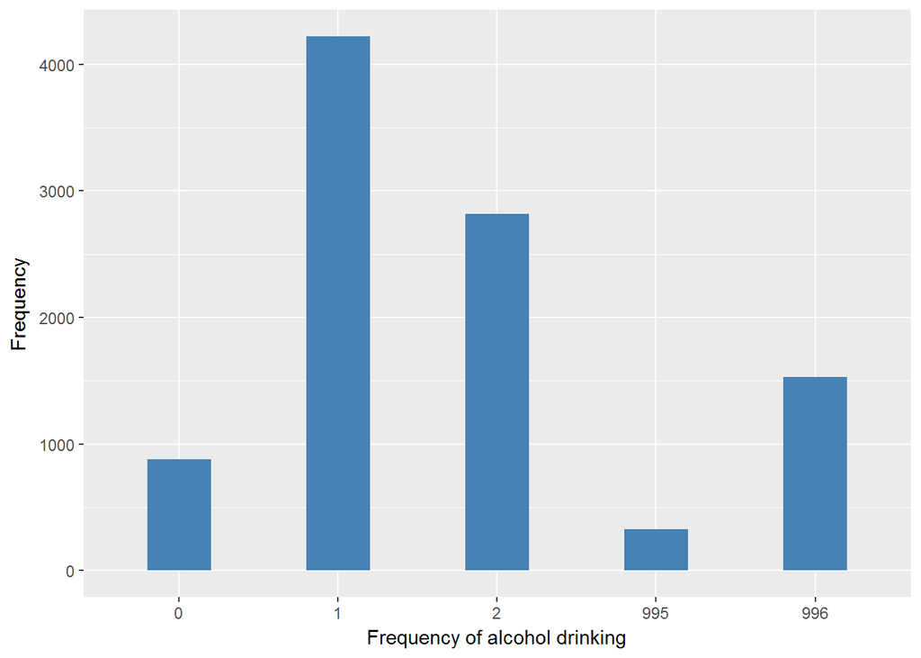

#### 2.1.3.4 Validation

### 2.1.4 Wave 4

#### 2.1.4.1 Study-specific variable description

| **Name** | `scako` |
| --- | --- |
| **Label** | `How often respondent has had an alcoholic drink during the last 12 months` |
| **Table name** | `wave_4_elsa_data_v3` |
| **Categories** | `1 = Almost every day` `2 = Five or six days a week` `3 = Three or four days a week` `4 = Once or twice a week` `5 = Once or twice a month` `6 = Once every couple of months` `7 = Once or twice a year`… |
| **Missings** | `-1 = Not applicable` `-9 = Not answered` |
| **Description** |  |

scako

| Sample size | Missing values |
| --- | --- |
| 11050 | 1947 |

Category

|  | 1 | 2 | 3 | 4 | 5 | 6 | 7 | 8 |
| --- | --- | --- | --- | --- | --- | --- | --- | --- |
| Frequency | 1484.00 | 621.00 | 1241.00 | 2259.00 | 1031.00 | 642.00 | 791.00 | 1034.00 |
| Percentage | 13.43 | 5.62 | 11.23 | 20.44 | 9.33 | 5.81 | 7.16 | 9.36 |

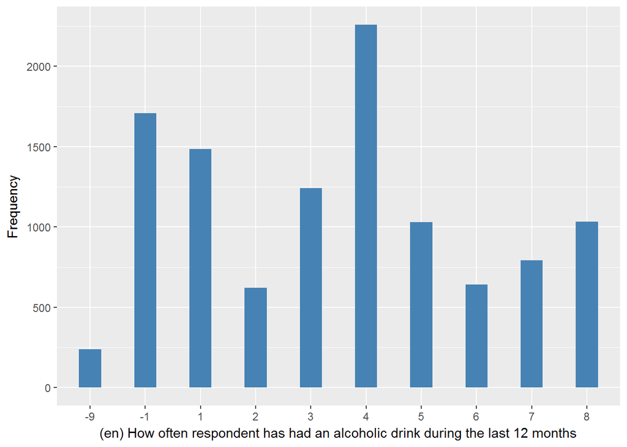

#### 2.1.4.2 Harmonisation algorithm

To compute `current_oh` from the study-specific variable it has to be recoded as follows:

- `1,2,3,4,5,6,7 into 1`
- `8 into 0`
- `-1 into 996`
- `-9 into 995`

To compute `freq_oh` from the study-specific variable it has to be recoded as follows:

- `1,2,3 into 2`
- `4,5,6,7 into 1`
- `8 into 0`
- `-1 into 996`
- `-9 into 995`

**R script:**

```r
ELSA_ds_w4 <- tibble(id = ELSA_w4$id)
ELSA_ds_w4$current_oh <- car::recode(ELSA_w4$scako, "c(1,2,3,4,5,6,7) = 1; c(8) = 0; -1 = 996; -9 = 995")
ELSA_ds_w4$freq_oh <- car::recode(ELSA_w4$scako, "c(1,2,3) = 2; c(4,5,6,7) = 1; c(8) = 0; -1 = 996; -9 = 995")
```

#### 2.1.4.3 Statistics of the new harmonized variable

Current alcohol drinker

| Sample size | Missing values |
| --- | --- |
| 11050 | 1947 |

Category

|  | 0 | 1 |
| --- | --- | --- |
| Frequency | 1034.00 | 8069.00 |
| Percentage | 9.36 | 73.02 |

Type of missing

|  | 991 | 992 | 993 | 994 | 995 | 996 | 997 | 998 | 999 | NA |
| --- | --- | --- | --- | --- | --- | --- | --- | --- | --- | --- |
| Frequency | 0 | 0 | 0 | 0 | 239.00 | 1708.00 | 0 | 0 | 0 | 0 |
| Percentage | 0 | 0 | 0 | 0 | 2.16 | 15.46 | 0 | 0 | 0 | 0 |

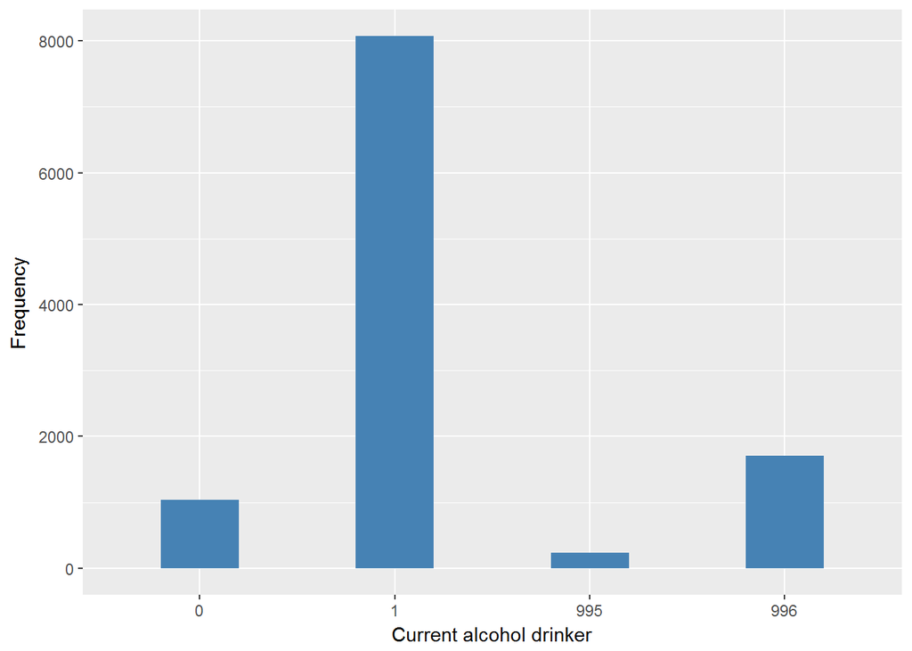

Frequency of alcohol drinking

| Sample size | Missing values |
| --- | --- |
| 11050 | 1947 |

Category

|  | 0 | 1 | 2 |
| --- | --- | --- | --- |
| Frequency | 1034.00 | 4723.00 | 3346.00 |
| Percentage | 9.36 | 42.74 | 30.28 |

Type of missing

|  | 991 | 992 | 993 | 994 | 995 | 996 | 997 | 998 | 999 | NA |
| --- | --- | --- | --- | --- | --- | --- | --- | --- | --- | --- |
| Frequency | 0 | 0 | 0 | 0 | 239.00 | 1708.00 | 0 | 0 | 0 | 0 |
| Percentage | 0 | 0 | 0 | 0 | 2.16 | 15.46 | 0 | 0 | 0 | 0 |

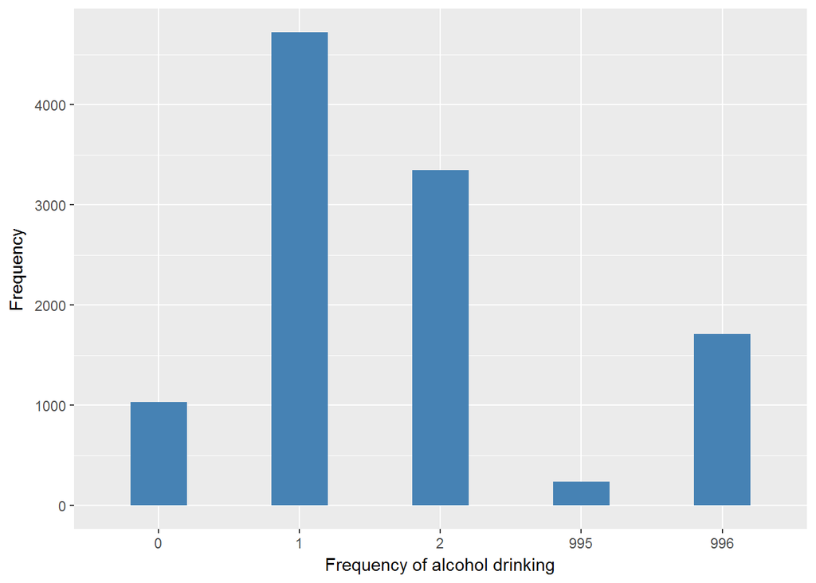

#### 2.1.4.4 Validation

### 2.1.5 Wave 5

#### 2.1.5.1 Study-specific variable description

| **Name** | `scako` |
| --- | --- |
| **Label** | `How often respondent has had an alcoholic drink during the last 12 months` |
| **Table name** | `wave_5_elsa_data_v4` |
| **Categories** | `1 = Almost every day` `2 = Five or six days a week` `3 = Three or four days a week` `4 = Once or twice a week` `5 = Once or twice a month` `6 = Once every couple of months` `7 = Once or twice a year`… |
| **Missings** | `-1 = Item not applicable` `-2 = Schedule Not Applicable` `-9 = Not answered` |
| **Description** |  |

scako

| Sample size | Missing values |
| --- | --- |
| 10274 | 1412 |

Category

|  | 1 | 2 | 3 | 4 | 5 | 6 | 7 | 8 |
| --- | --- | --- | --- | --- | --- | --- | --- | --- |
| Frequency | 1474.00 | 507.00 | 1156.00 | 2095.00 | 1032.00 | 628.00 | 865.00 | 1105.00 |
| Percentage | 14.35 | 4.93 | 11.25 | 20.39 | 10.04 | 6.11 | 8.42 | 10.76 |

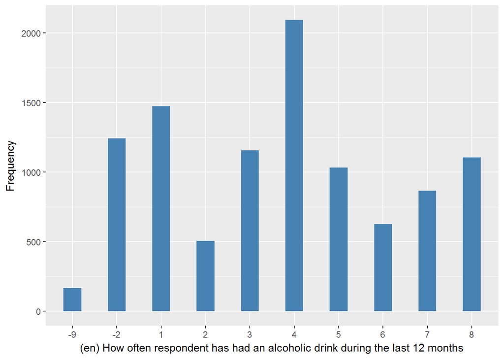

#### 2.1.5.2 Harmonisation algorithm

To compute `current_oh` from the study-specific variable it has to be recoded as follows:

- `1,2,3,4,5,6,7 into 1`
- `8 into 0`
- `-1,-2 into 996`
- `-9 into 995`

To compute `freq_oh` from the study-specific variable it has to be recoded as follows:

- `1,2,3 into 2`
- `4,5,6,7 into 1`
- `8 into 0`
- `-1,-2 into 996`
- `-9 into 995`

**R script:**

```r
ELSA_ds_w5 <- tibble(id = ELSA_w5$id)
ELSA_ds_w5$current_oh <- car::recode(ELSA_w5$scako, "c(1,2,3,4,5,6,7) = 1; c(8) = 0; c(-1,-2) = 996; -9 = 995")
ELSA_ds_w5$freq_oh <- car::recode(ELSA_w5$scako, "c(1,2,3) = 2; c(4,5,6,7) = 1; c(8) = 0; c(-1,-2) = 996; -9 = 995")
```

#### 2.1.5.3 Statistics of the new harmonized variable

Current alcohol drinker

| Sample size | Missing values |
| --- | --- |
| 10274 | 1412 |

Category

|  | 0 | 1 |
| --- | --- | --- |
| Frequency | 1105.00 | 7757.0 |
| Percentage | 10.76 | 75.5 |

Type of missing

|  | 991 | 992 | 993 | 994 | 995 | 996 | 997 | 998 | 999 | NA |
| --- | --- | --- | --- | --- | --- | --- | --- | --- | --- | --- |
| Frequency | 0 | 0 | 0 | 0 | 168.00 | 1244.00 | 0 | 0 | 0 | 0 |
| Percentage | 0 | 0 | 0 | 0 | 1.64 | 12.11 | 0 | 0 | 0 | 0 |

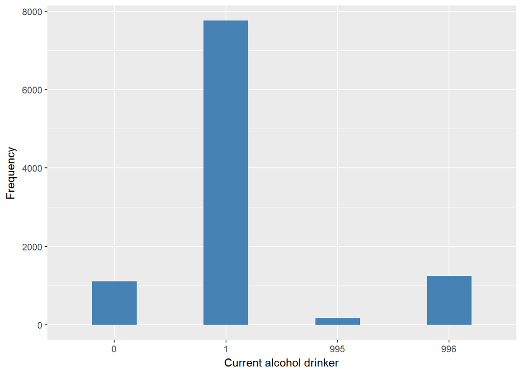

Frequency of alcohol drinking

| Sample size | Missing values |
| --- | --- |
| 10274 | 1412 |

Category

|  | 0 | 1 | 2 |
| --- | --- | --- | --- |
| Frequency | 1105.00 | 4620.00 | 3137.00 |
| Percentage | 10.76 | 44.97 | 30.53 |

Type of missing

|  | 991 | 992 | 993 | 994 | 995 | 996 | 997 | 998 | 999 | NA |
| --- | --- | --- | --- | --- | --- | --- | --- | --- | --- | --- |
| Frequency | 0 | 0 | 0 | 0 | 168.00 | 1244.00 | 0 | 0 | 0 | 0 |
| Percentage | 0 | 0 | 0 | 0 | 1.64 | 12.11 | 0 | 0 | 0 | 0 |

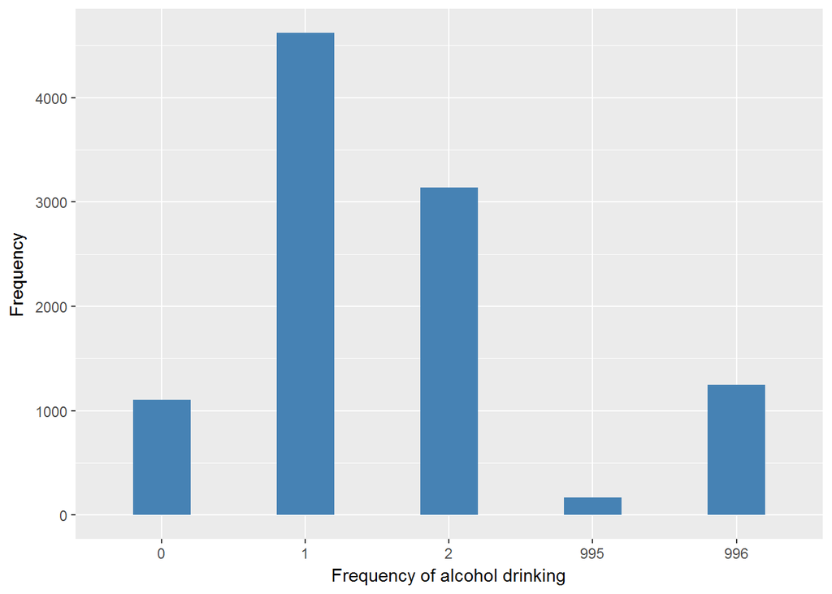

#### 2.1.5.4 Validation

### 2.1.6 Wave 6

#### 2.1.6.1 Study-specific variable description

| **Name** | `scako` |
| --- | --- |
| **Label** | `How often respondent has had an alcoholic drink during the last 12 months` |
| **Table name** | `wave_6_elsa_data_v2` |
| **Categories** | `1 = Almost every day` `2 = Five or six days a week` `3 = Three or four days a week` `4 = Once or twice a week` `5 = Once or twice a month` `6 = Once every couple of months` `7 = Once or twice a year`… |
| **Missings** | `-1 = Item not applicable` `-2 = Schedule Not Applicable` `-9 = Not answered` |
| **Description** |  |

scako

| Sample size | Missing values |
| --- | --- |
| 10601 | 1771 |

Category

|  | 1 | 2 | 3 | 4 | 5 | 6 | 7 | 8 |
| --- | --- | --- | --- | --- | --- | --- | --- | --- |
| Frequency | 1298.00 | 559.00 | 1270.00 | 2058.00 | 1018.0 | 637.00 | 813.00 | 1177.0 |
| Percentage | 12.24 | 5.27 | 11.98 | 19.41 | 9.6 | 6.01 | 7.67 | 11.1 |

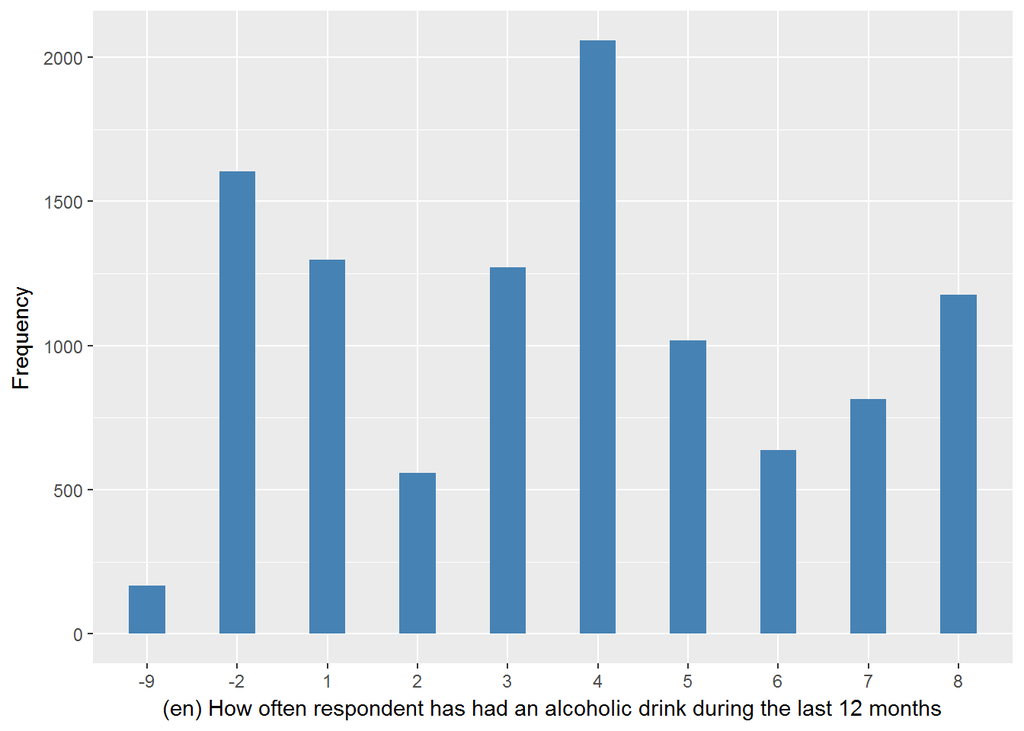

#### 2.1.6.2 Harmonisation algorithm

To compute `current_oh` from the study-specific variable it has to be recoded as follows:

- `1,2,3,4,5,6,7 into 1`
- `8 into 0`
- `-1,-2 into 996`
- `-9 into 995`

To compute `freq_oh` from the study-specific variable it has to be recoded as follows:

- `1,2,3 into 2`
- `4,5,6,7 into 1`
- `8 into 0`
- `-1,-2 into 996`
- `-9 into 995`

**R script:**

```r
ELSA_ds_w6 <- tibble(id = ELSA_w6$id)
ELSA_ds_w6$current_oh <- car::recode(ELSA_w6$scako, "c(1,2,3,4,5,6,7) = 1; c(8) = 0; c(-1,-2) = 996; -9 = 995")
ELSA_ds_w6$freq_oh <- car::recode(ELSA_w6$scako, "c(1,2,3) = 2; c(4,5,6,7) = 1; c(8) = 0; c(-1,-2) = 996; -9 = 995")
```

#### 2.1.6.3 Statistics of the new harmonized variable

Current alcohol drinker

| Sample size | Missing values |
| --- | --- |
| 10601 | 1771 |

Category

|  | 0 | 1 |
| --- | --- | --- |
| Frequency | 1177.0 | 7653.00 |
| Percentage | 11.1 | 72.19 |

Type of missing

|  | 991 | 992 | 993 | 994 | 995 | 996 | 997 | 998 | 999 | NA |
| --- | --- | --- | --- | --- | --- | --- | --- | --- | --- | --- |
| Frequency | 0 | 0 | 0 | 0 | 167.00 | 1604.00 | 0 | 0 | 0 | 0 |
| Percentage | 0 | 0 | 0 | 0 | 1.58 | 15.13 | 0 | 0 | 0 | 0 |

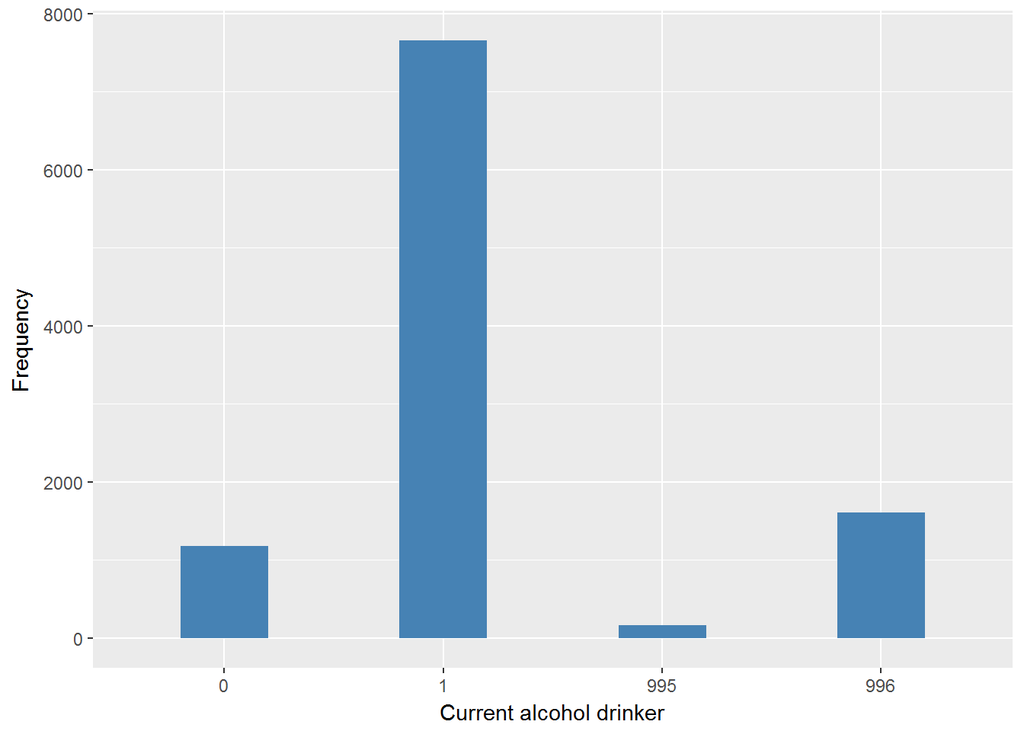

Frequency of alcohol drinking

| Sample size | Missing values |
| --- | --- |
| 10601 | 1771 |

Category

|  | 0 | 1 | 2 |
| --- | --- | --- | --- |
| Frequency | 1177.0 | 4526.00 | 3127.0 |
| Percentage | 11.1 | 42.69 | 29.5 |

Type of missing

|  | 991 | 992 | 993 | 994 | 995 | 996 | 997 | 998 | 999 | NA |
| --- | --- | --- | --- | --- | --- | --- | --- | --- | --- | --- |
| Frequency | 0 | 0 | 0 | 0 | 167.00 | 1604.00 | 0 | 0 | 0 | 0 |
| Percentage | 0 | 0 | 0 | 0 | 1.58 | 15.13 | 0 | 0 | 0 | 0 |

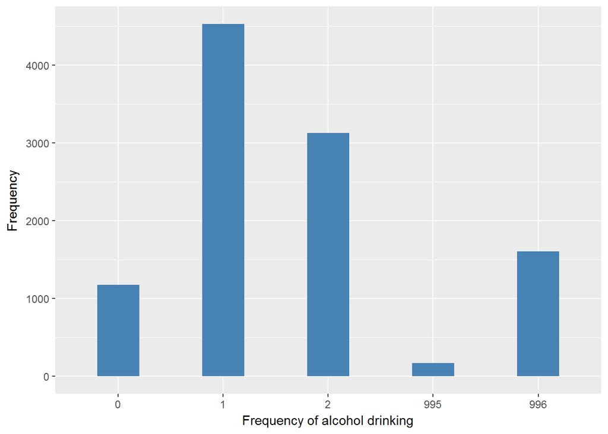

#### 2.1.6.4 Validation

### 2.1.7 Wave 7

| **Name** | `scako` |
| --- | --- |
| **Label** | `How often respondent has had an alcoholic drink during the last 12 months` |
| **Table name** | `wave_7_elsa_data` |
| **Categories** | `1 = Almost every day` `2 = Five or six days a week` `3 = Three or four days a week` `4 = Once or twice a week` `5 = Once or twice a month` `6 = Once every couple of months` `7 = Once or twice a year`… |
| **Missings** | `-1 = Item not applicable` `-2 = Schedule Not Applicable` `-9 = Not answered` |
| **Description** |  |

scako

| Sample size | Missing values |
| --- | --- |
| 9666 | 1635 |

Category

|  | 1 | 2 | 3 | 4 | 5 | 6 | 7 | 8 |
| --- | --- | --- | --- | --- | --- | --- | --- | --- |
| Frequency | 1065.00 | 516.00 | 1098.00 | 1998.00 | 935.00 | 619.0 | 741.00 | 1059.00 |
| Percentage | 11.02 | 5.34 | 11.36 | 20.67 | 9.67 | 6.4 | 7.67 | 10.96 |

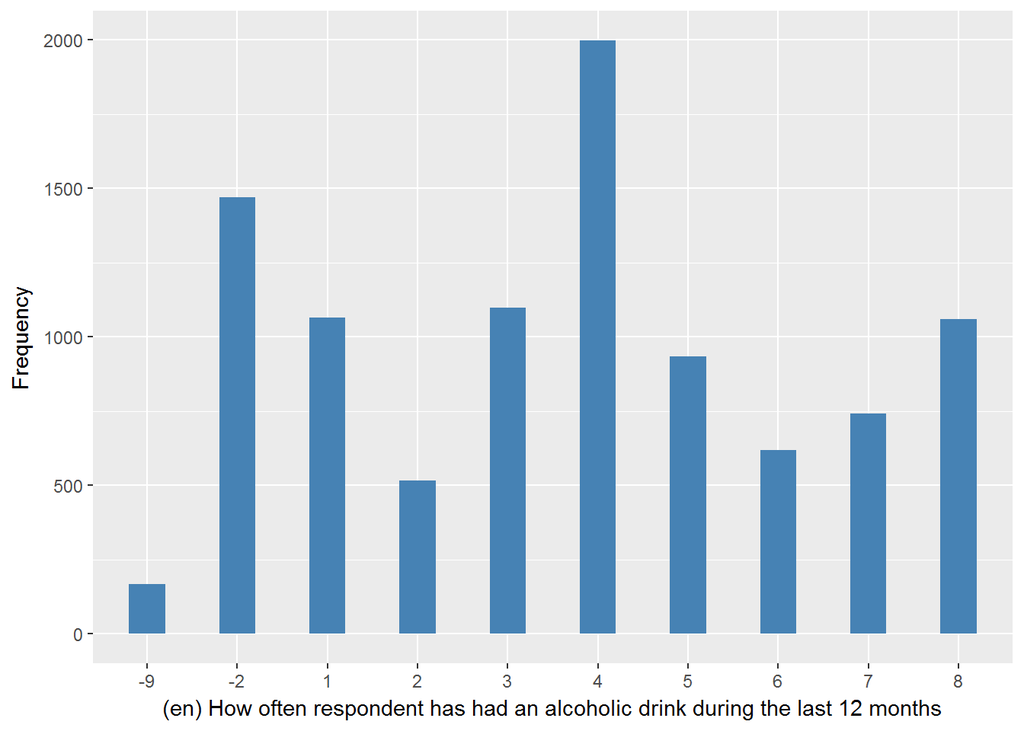

#### 2.1.7.1 Harmonisation algorithm

To compute `current_oh` from the study-specific variable it has to be recoded as follows:

- `1,2,3,4,5,6,7 into 1`
- `8 into 0`
- `-1,-2 into 996`
- `-9 into 995`

To compute `freq_oh` from the study-specific variable it has to be recoded as follows:

- `1,2,3 into 2`
- `4,5,6,7 into 1`
- `8 into 0`
- `-1,-2 into 996`
- `-9 into 995`

**R script:**

```r
ELSA_ds_w7 <- tibble(id = ELSA_w7$id)
ELSA_ds_w7$current_oh <- car::recode(ELSA_w7$scako, "c(1,2,3,4,5,6,7) = 1; c(8) = 0; c(-1,-2) = 996; -9 = 995")
ELSA_ds_w7$freq_oh <- car::recode(ELSA_w7$scako, "c(1,2,3) = 2; c(4,5,6,7) = 1; c(8) = 0; c(-1,-2) = 996; -9 = 995")
```

#### 2.1.7.2 Statistics of the new harmonized variable

Current alcohol drinker

| Sample size | Missing values |
| --- | --- |
| 9666 | 1635 |

Category

|  | 0 | 1 |
| --- | --- | --- |
| Frequency | 1059.00 | 6972.00 |
| Percentage | 10.96 | 72.13 |

Type of missing

|  | 991 | 992 | 993 | 994 | 995 | 996 | 997 | 998 | 999 | NA |
| --- | --- | --- | --- | --- | --- | --- | --- | --- | --- | --- |
| Frequency | 0 | 0 | 0 | 0 | 166.00 | 1469.0 | 0 | 0 | 0 | 0 |
| Percentage | 0 | 0 | 0 | 0 | 1.72 | 15.2 | 0 | 0 | 0 | 0 |

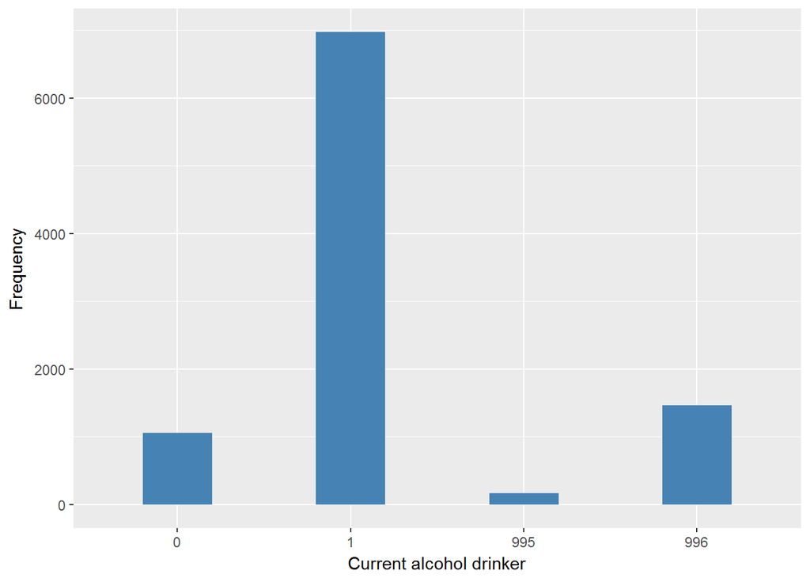

Frequency of alcohol drinking

| Sample size | Missing values |
| --- | --- |
| 9666 | 1635 |

Category

|  | 0 | 1 | 2 |
| --- | --- | --- | --- |
| Frequency | 1059.00 | 4293.00 | 2679.00 |
| Percentage | 10.96 | 44.41 | 27.72 |

Type of missing

|  | 991 | 992 | 993 | 994 | 995 | 996 | 997 | 998 | 999 | NA |
| --- | --- | --- | --- | --- | --- | --- | --- | --- | --- | --- |
| Frequency | 0 | 0 | 0 | 0 | 166.00 | 1469.0 | 0 | 0 | 0 | 0 |
| Percentage | 0 | 0 | 0 | 0 | 1.72 | 15.2 | 0 | 0 | 0 | 0 |

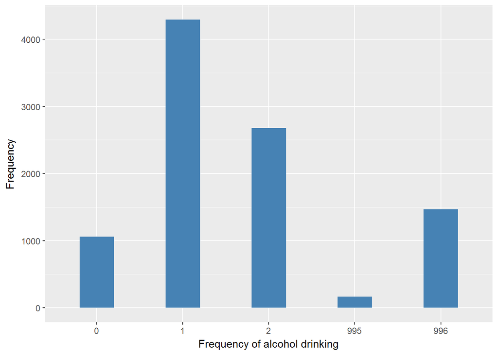

#### 2.1.7.3 Validation

## 2.2 Summary of descriptive statistics of the harmonised variable `current_oh` accross populations and waves

Two tables are generated:

1. Percentages of categories in each harmonised variable.
2. Frequencies and percentages of individuals with different trajectories. To avoid too large table, Only trajectories with percentages larger than 0.3 are shown.

```r
t.hds <- frq(l.hds[[1]][2])[[1]][, c(1, 2)]
for (i in seq_along(l.hds)) {
    t.hds[2 + i] <- frq(l.hds[[i]][2])[[1]][, 4]
}
t.hds[13, ] <- c("n", "sample size", sapply(l.hds, function(wave) length(wave[[1]])))
names(t.hds) <- c("val", "label", names(l.hds))
kable(t.hds)
```

| val | label | w1 | w2 | w3 | w4 | w5 | w6 | w7 |
| --- | --- | --- | --- | --- | --- | --- | --- | --- |
| 0 | No | 11.53 | 9.36 | 9 | 9.36 | 10.76 | 11.1 | 10.96 |
| 1 | Yes | 86.86 | 76.98 | 72.03 | 73.02 | 75.5 | 72.19 | 72.13 |
| 991 | CAPI interviewer error | 0 | 0 | 0 | 0 | 0 | 0 | 0 |
| 992 | Impute | 0 | 0 | 0 | 0 | 0 | 0 | 0 |
| 993 | Disable to measure | 0 | 0 | 0 | 0 | 0 | 0 | 0 |
| 994 | Not attempt not done | 0 | 0 | 0 | 0 | 0 | 0 | 0 |
| 995 | Does not answer | 0 | 2.29 | 3.35 | 2.16 | 1.64 | 1.58 | 1.72 |
| 996 | Not applicable | 1.45 | 11.37 | 15.63 | 15.46 | 12.11 | 15.13 | 15.2 |
| 997 | Refuse | 0.04 | 0 | 0 | 0 | 0 | 0 | 0 |
| 998 | Do not know | 0.12 | 0 | 0 | 0 | 0 | 0 | 0 |
| 999 | Missing | 0 | 0 | 0 | 0 | 0 | 0 | 0 |
| NA | NA | 0 | 0 | 0 | 0 | 0 | 0 | 0 |
| n | sample size | 12099 | 9432 | 9771 | 11050 | 10274 | 10601 | 9666 |

```r
dbb <- get(paste0("ELSA_m_ds_", names(l.hds)[1]))[, c("id", "current_oh")]
for (ind in 2:length(l.hds)) {
    dbb <- merge(dbb, get(paste0("ELSA_m_ds_", names(l.hds)[ind]))[, c("id",
        "current_oh")], by = "id", suffixes = c("", paste0(".", names(l.hds)[ind])),
        all = T)
}
names(dbb) <- c("id", names(l.hds))

v.dbb <- dbb[, 2]
for (ind in 2:length(l.hds)) {
    v.dbb <- paste(v.dbb, dbb[, ind + 1], sep = "")
}
f.dbb <- frq(v.dbb)[[1]][, c(1, 2, 4)]
kable(f.dbb[f.dbb[, 3] >= 0.3, ])
```

|  | val | frq | raw.prc |
| --- | --- | --- | --- |
| 1 | 0000000 | 97 | 0.52 |
| 36 | 000NANANANA | 62 | 0.34 |
| 84 | 00NANANANANA | 121 | 0.65 |
| 213 | 0NANANANANANA | 481 | 2.60 |
| 304 | 10NANANANANA | 75 | 0.41 |
| 379 | 1111110 | 57 | 0.31 |
| 380 | 1111111 | 2415 | 13.06 |
| 381 | 111111NA | 410 | 2.22 |
| 383 | 11111NA1 | 105 | 0.57 |
| 384 | 11111NANA | 322 | 1.74 |
| 389 | 1111NA11 | 62 | 0.34 |
| 393 | 1111NANANA | 319 | 1.73 |
| 405 | 111NA111 | 176 | 0.95 |
| 406 | 111NA11NA | 61 | 0.33 |
| 416 | 111NANANANA | 620 | 3.35 |
| 441 | 11NA1111 | 190 | 1.03 |
| 445 | 11NA11NANA | 56 | 0.30 |
| 452 | 11NA1NANANA | 80 | 0.43 |
| 463 | 11NANA111 | 63 | 0.34 |
| 474 | 11NANANANANA | 1041 | 5.63 |
| 510 | 1NA11111 | 121 | 0.65 |
| 535 | 1NA1NANANANA | 138 | 0.75 |
| 552 | 1NANA1111 | 58 | 0.31 |
| 582 | 1NANANANANANA | 2245 | 12.14 |
| 655 | NANA11111 | 467 | 2.53 |
| 656 | NANA1111NA | 88 | 0.48 |
| 659 | NANA111NANA | 58 | 0.31 |
| 667 | NANA11NANANA | 78 | 0.42 |
| 675 | NANA1NA111 | 57 | 0.31 |
| 684 | NANA1NANANANA | 217 | 1.17 |
| 685 | NANANA0000 | 78 | 0.42 |
| 709 | NANANA0NANANA | 57 | 0.31 |
| 722 | NANANA1111 | 1096 | 5.93 |
| 723 | NANANA111NA | 218 | 1.18 |
| 725 | NANANA11NA1 | 80 | 0.43 |
| 726 | NANANA11NANA | 159 | 0.86 |
| 731 | NANANA1NA11 | 75 | 0.41 |
| 735 | NANANA1NANANA | 270 | 1.46 |
| 749 | NANANANA111 | 138 | 0.75 |
| 750 | NANANANA11NA | 66 | 0.36 |
| 753 | NANANANA1NANA | 74 | 0.40 |
| 758 | NANANANANA11 | 632 | 3.42 |
| 759 | NANANANANA1NA | 216 | 1.17 |
| 761 | NANANANANANA1 | 446 | 2.41 |
| 762 | NANANANANANANA | 1017 | 5.50 |

## 2.3 Summary of descriptive statistics of the harmonised variable `freq_oh` accross populations and waves

Two tables are generated:

1. Percentages of categories in each harmonised variable.
2. Frequencies and percentages of individuals with different trajectories. To avoid too large table, Only trajectories with percentages larger than 0.3 are shown.

```r
t.hds <- frq(l.hds[[1]][3])[[1]][, c(1, 2)]
for (i in seq_along(l.hds)) {
    t.hds[2 + i] <- frq(l.hds[[i]][3])[[1]][, 4]
}
t.hds[14, ] <- c("n", "sample size", sapply(l.hds, function(wave) length(wave[[1]])))
names(t.hds) <- c("val", "label", names(l.hds))
kable(t.hds)
```

| val | label | w1 | w2 | w3 | w4 | w5 | w6 | w7 |
| --- | --- | --- | --- | --- | --- | --- | --- | --- |
| 0 | never | 11.53 | 9.36 | 9 | 9.36 | 10.76 | 11.1 | 10.96 |
| 1 | rare | 59.4 | 46.36 | 43.19 | 42.74 | 44.97 | 42.69 | 44.41 |
| 2 | often | 27.46 | 30.62 | 28.84 | 30.28 | 30.53 | 29.5 | 27.72 |
| 991 | CAPI interviewer error | 0 | 0 | 0 | 0 | 0 | 0 | 0 |
| 992 | Impute | 0 | 0 | 0 | 0 | 0 | 0 | 0 |
| 993 | Disable to measure | 0 | 0 | 0 | 0 | 0 | 0 | 0 |
| 994 | Not attempt not done | 0 | 0 | 0 | 0 | 0 | 0 | 0 |
| 995 | Does not answer | 0 | 2.29 | 3.35 | 2.16 | 1.64 | 1.58 | 1.72 |
| 996 | Not applicable | 1.45 | 11.37 | 15.63 | 15.46 | 12.11 | 15.13 | 15.2 |
| 997 | Refuse | 0.04 | 0 | 0 | 0 | 0 | 0 | 0 |
| 998 | Do not know | 0.12 | 0 | 0 | 0 | 0 | 0 | 0 |
| 999 | Missing | 0 | 0 | 0 | 0 | 0 | 0 | 0 |
| NA | NA | 0 | 0 | 0 | 0 | 0 | 0 | 0 |
| n | sample size | 12099 | 9432 | 9771 | 11050 | 10274 | 10601 | 9666 |

```r
dbb <- get(paste0("ELSA_m_ds_", names(l.hds)[1]))[, c("id", "freq_oh")]
for (ind in 2:length(l.hds)) {
    dbb <- merge(dbb, get(paste0("ELSA_m_ds_", names(l.hds)[ind]))[, c("id",
        "freq_oh")], by = "id", suffixes = c("", paste0(".", names(l.hds)[ind])),
        all = T)
}
names(dbb) <- c("id", names(l.hds))

v.dbb <- dbb[, 2]
for (ind in 2:length(l.hds)) {
    v.dbb <- paste(v.dbb, dbb[, ind + 1], sep = "")
}
f.dbb <- frq(v.dbb)[[1]][, c(1, 2, 4)]
kable(f.dbb[f.dbb[, 3] >= 0.3, ])
```

|  | val | frq | raw.prc |
| --- | --- | --- | --- |
| 1 | 0000000 | 97 | 0.52 |
| 40 | 000NANANANA | 62 | 0.34 |
| 89 | 00NANANANANA | 121 | 0.65 |
| 232 | 0NANANANANANA | 481 | 2.60 |
| 323 | 10NANANANANA | 72 | 0.39 |
| 397 | 1111111 | 896 | 4.85 |
| 399 | 111111NA | 161 | 0.87 |
| 407 | 11111NANA | 150 | 0.81 |
| 428 | 1111NANANA | 141 | 0.76 |
| 458 | 111NA111 | 69 | 0.37 |
| 478 | 111NANANANA | 305 | 1.65 |
| 558 | 11NA1111 | 84 | 0.45 |
| 622 | 11NANANANANA | 569 | 3.08 |
| 726 | 1222222 | 129 | 0.70 |
| 796 | 12NANANANANA | 103 | 0.56 |
| 870 | 1NA1NANANANA | 78 | 0.42 |
| 967 | 1NANANANANANA | 1592 | 8.61 |
| 1073 | 21NANANANANA | 59 | 0.32 |
| 1157 | 2222222 | 560 | 3.03 |
| 1158 | 222222NA | 108 | 0.58 |
| 1161 | 22222NANA | 63 | 0.34 |
| 1171 | 2222NANANA | 86 | 0.47 |
| 1193 | 222NANANANA | 154 | 0.83 |
| 1241 | 22NANANANANA | 310 | 1.68 |
| 1348 | 2NANANANANANA | 653 | 3.53 |
| 1437 | NANA11111 | 205 | 1.11 |
| 1507 | NANA1NANANANA | 129 | 0.70 |
| 1538 | NANA22222 | 123 | 0.67 |
| 1569 | NANA2NANANANA | 88 | 0.48 |
| 1570 | NANANA0000 | 78 | 0.42 |
| 1594 | NANANA0NANANA | 57 | 0.31 |
| 1608 | NANANA1111 | 463 | 2.50 |
| 1610 | NANANA111NA | 87 | 0.47 |
| 1617 | NANANA11NANA | 91 | 0.49 |
| 1640 | NANANA1NANANA | 151 | 0.82 |
| 1661 | NANANA2222 | 356 | 1.93 |
| 1662 | NANANA222NA | 71 | 0.38 |
| 1675 | NANANA2NANANA | 119 | 0.64 |
| 1689 | NANANANA111 | 67 | 0.36 |
| 1712 | NANANANANA11 | 347 | 1.88 |
| 1714 | NANANANANA1NA | 132 | 0.71 |
| 1717 | NANANANANA22 | 206 | 1.11 |
| 1718 | NANANANANA2NA | 84 | 0.45 |
| 1720 | NANANANANANA1 | 307 | 1.66 |
| 1721 | NANANANANANA2 | 139 | 0.75 |
| 1722 | NANANANANANANA | 1017 | 5.50 |

# 3 Quality estimation

- Past drinking cannot be harmonized.